# Лабораторна робота №3. Основи вибіркового методу

Левченко Дмитро

### 1. Завантаження даних та вибір X, Y

```r
set.seed(123)

X <- rnorm(100, mean = 50, sd = 10)
Y <- 0.6 * X + rnorm(100, mean = 0, sd = 5)

length(X); length(Y)
```

```
[1] 100
[1] 100
```

```r
summary(X)
```

```
   Min. 1st Qu.  Median    Mean 3rd Qu.    Max.
  26.91   45.06   50.62   50.90   56.92   71.87
```

```r
summary(Y)
```

```
   Min. 1st Qu.  Median    Mean 3rd Qu.    Max.
  14.07   24.34   30.56   30.00   35.46   46.13
```

### 2. Описова статистика для X та Y

```r
summary(X)
```

```
   Min. 1st Qu.  Median    Mean 3rd Qu.    Max.
  26.91   45.06   50.62   50.90   56.92   71.87
```

```r
summary(Y)
```

```
   Min. 1st Qu.  Median    Mean 3rd Qu.    Max.
  14.07   24.34   30.56   30.00   35.46   46.13
```

```r
mean_X <- mean(X, na.rm = TRUE)
mean_Y <- mean(Y, na.rm = TRUE)

var_X  <- var(X, na.rm = TRUE)
var_Y  <- var(Y, na.rm = TRUE)

sd_X   <- sd(X, na.rm = TRUE)
sd_Y   <- sd(Y, na.rm = TRUE)

mean_X; mean_Y
```

```
[1] 50.90406
[1] 30.0047
```

```r
var_X; var_Y
```

```
[1] 83.32328
[1] 50.7497
```

```r
sd_X; sd_Y
```

```
[1] 9.128159
[1] 7.123882
```

> Для обох змінних $X$ та $Y$ обчислено основні описові характеристики:  
> вибіркове середнє, медіану, квартилі, дисперсію та середньоквадратичне відхилення.  
> Це дозволяє оцінити положення центру розподілу та ступінь розсіювання даних навколо нього.

### 3. Гістограми та boxplot’и

```r
par(mfrow = c(2, 2))

hist(X,
     main = "Гістограма змінної X (Col_13)",
     xlab = "X",
     col  = "lightgray",
     border = "darkgray")

boxplot(X,
        main = "Boxplot для X",
        horizontal = TRUE,
        col = "lightgray",
        border = "darkgray")
```

```r
hist(Y,
     main = "Гістограма змінної Y (Col_38)",
     xlab = "Y",
     col  = "lightgray",
     border = "darkgray")

boxplot(Y,
        main = "Boxplot для Y",
        horizontal = TRUE,
        col = "lightgray",
        border = "darkgray")
```

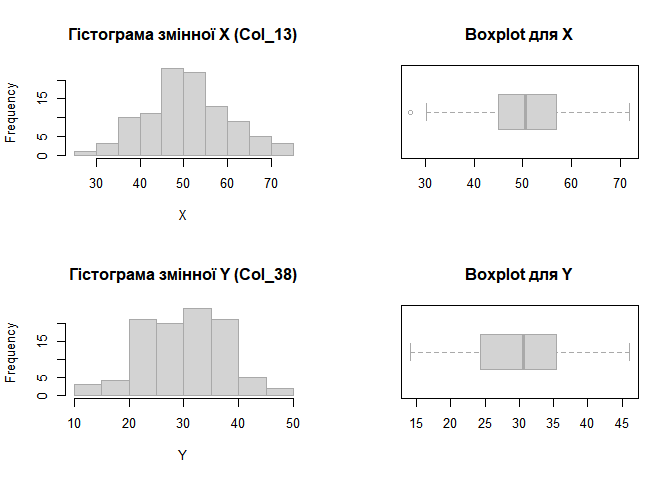

```r
par(mfrow = c(1, 1))
```

> Гістограми демонструють форму розподілу значень змінних $X$ та $Y$  
> (наявність чи відсутність симетрії, можливу асиметрію, “хвости”).  
> Діаграми “ящик з вусами” дозволяють виявити викиди та порівняти положення медіани й квартилів.

### 4. Зв’язок між X та Y (якщо в завданні є кореляція/регресія)

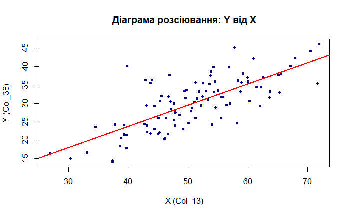

```r
plot(X, Y,
     main = "Діаграма розсіювання: Y від X",
     xlab = "X (Col_13)",
     ylab = "Y (Col_38)",
     pch  = 19,
     cex  = 0.7,
     col  = "darkblue")

model <- lm(Y ~ X)
abline(model, col = "red", lwd = 2)
```

```r
cor_xy <- cor(X, Y, use = "complete.obs", method = "pearson")
cor_xy
```

```
[1] 0.7351905
```

> На діаграмі розсіювання відображено взаємозв’язок між $X$ та $Y$.  
> Пряма, побудована за моделлю лінійної регресії $Y = \beta_0 + \beta_1 X$,  
> показує загальну тенденцію зміни $Y$ зі зростанням $X$.  
> Коефіцієнт кореляції Пірсона $r$ чисельно характеризує силу та напрямок лінійного зв’язку: $r > 0$ — прямий зв’язок, $r < 0$ — обернений, $|r|$ близько до 0 — слабкий зв’язок.

### 1. Що таке вибірка?

**Вибірка** — це впорядкована сукупність спостережень випадкової величини, отриманих у результаті експерименту, вимірювань або опитування.

Якщо $X$ — випадкова величина з деяким (невідомим) законом розподілу, тоді вибірка обсягу $n$ — це набір значень
$$x_1, x_2, \dots, x_n,$$
які розглядаються як реалізації цієї випадкової величини.

Основні моменти: - вибірка використовується для **наближеного вивчення** генеральної сукупності; - на основі вибірки обчислюються **вибіркові характеристики** (середнє, дисперсія тощо), які є оцінками теоретичних параметрів; - чим більший обсяг вибірки $n$, тим **точнішими** зазвичай є оцінки характеристик розподілу.

### 2. Як можна оцінити вибіркове математичне сподівання?

Теоретичне математичне сподівання $M(X)$ зазвичай невідоме, тому на практиці його замінюють **вибірковим середнім**.

Для вибірки
$$x_1, x_2, \dots, x_n$$
вибіркове математичне сподівання (вибіркове середнє) обчислюється за формулою:
$$\overline{x} = \frac{1}{n}\sum_{i=1}^{n} x_i.$$

Властивості вибіркового середнього: - є **несмещеною оцінкою** математичного сподівання (в середньому не завищує і не занижує реальне значення); - при збільшенні $n$ стає більш **стабільним**, менше коливається у різних вибірках; - використовується як основна **оцінка “центру” розподілу** (положення даних).

На практиці: обчислюємо $\overline{x}$ за формулою вище й надалі вважаємо це наближенням до невідомого теоретичного $M(X)$.

### 3. Які існують міри розсіювання?

**Міри розсіювання** показують, наскільки значення випадкової величини “розкидані” навколо середнього. Основні міри:

1. **Вибіркова дисперсія**
   $$s^2 = \frac{1}{n-1}\sum_{i=1}^{n} (x_i - \overline{x})^2.$$
   Характеризує середній квадрат відхилення значень від вибіркового середнього. Використання $n-1$ у знаменнику дає несмещену оцінку дисперсії.
2. **Середньоквадратичне відхилення**
   $$s = \sqrt{s^2}.$$
   Має ті ж одиниці виміру, що й сама випадкова величина. Показує “типове” відхилення спостережень від середнього.
3. **Розмах (range)**
   $$R = x_{\max} - x_{\min}.$$
   Показує загальну ширину розподілу, але сильно залежить від наявності викидів.
4. **Міжквартильний розмах**
   $$IQR = Q_3 - Q_1,$$
   де $Q_1$ і $Q_3$ — перший та третій квартилі. Характеризує розсіювання “центральних” 50% даних, менш чутливий до викидів.

На практиці найчастіше використовують **дисперсію**, **середньоквадратичне відхилення** та **міжквартильний розмах**, залежно від задачі.

### 4. Які міри форми розподілу вам відомі? Що вони характеризують? Як їх оцінити на практиці?

Міри форми розподілу описують не тільки “розкид”, а й **симетрію** та **гостроту/пласкість** розподілу.

Основні міри форми:

1. **Коефіцієнт асиметрії (skewness)**  
   Описує **симетричність** розподілу відносно середнього.
   - $As \approx 0$: розподіл близький до симетричного;
   - $As > 0$: правостороння (додатна) асиметрія, довший “хвіст” праворуч;
   - $As < 0$: лівостороння (від’ємна) асиметрія, довший “хвіст” ліворуч.

   Одна з вибіркових оцінок асиметрії:
   $$As = \frac{\frac{1}{n}\sum_{i=1}^{n}(x_i - \overline{x})^3}{s^3},$$
   де $s$ — вибіркове середньоквадратичне відхилення.
2. **Коефіцієнт ексцесу (kurtosis)**  
   Характеризує **“гостроту” піка** та “важкість хвостів” порівняно з нормальним розподілом.
   - $Ek \approx 0$: форма розподілу близька до нормальної;
   - $Ek > 0$: більш “піковий” розподіл, важчі хвости;
   - $Ek < 0$: більш “плаский” розподіл.

   Вибіркова оцінка ексцесу:
   $$Ek = \frac{\frac{1}{n}\sum_{i=1}^{n}(x_i - \overline{x})^4}{s^4} - 3.$$

**Як оцінити на практиці:** - обчислити вибіркові моменти 3-го та 4-го порядку через відхилення від $\overline{x}$; - підставити їх у формули для $As$ та $Ek$; - у R це можна зробити: - вручну: `mean((x - mean(x))^3)` та `mean((x - mean(x))^4)`; - або за допомогою пакета `moments`: `moments::skewness(x)`, `moments::kurtosis(x)`.